# Compec VB R Workshop - Fall 2023

### Real world use cases of R:

[figure not shown]

### Python vs. R?

[figure not shown]

## Let’s start coding!

```r
# Addition
2 + 2
```

```
## [1] 4
```

```r
# Subtraction
3 - 2
```

```
## [1] 1
```

```r
# Multiplication
3 * 2
```

```
## [1] 6
```

```r
# Division
3 / 2
```

```
## [1] 1.5
```

```r
# Exponentiation
2 ^ 5
```

```
## [1] 32
```

```r
# Order of operations
2 + 3 * 4
```

```
## [1] 14
```

```r
(2 + 3) * 4
```

```
## [1] 20
```

## Functions in R

In R, instead of using mathematical operators like this, we will primarily use “functions” that allow us to perform various tasks. Each function takes specific arguments. Arguments are the inputs to the function, i.e., the objects on which the function operates. Some of these arguments may be required to be explicitly specified. If a function requires multiple arguments, the arguments are separated by commas.

Functions are a way to package up and reuse code.

The function below is called “add_two” and it adds two to any number you give it.

```r
add_two <- function(x) {
  x + 2
}
```

Now we can use the function we just created.

```r
add_two(3)
```

```
## [1] 5
```

Other functions are built into R. For example, the “log” function computes the natural logarithm.

```r
log(10)
```

```
## [1] 2.302585
```

```r
sqrt(4)
```

```
## [1] 2
```

```r
abs(-2)
```

```
## [1] 2
```

You can also use functions inside other functions.

```r
log(sqrt(4))
```

```
## [1] 0.6931472
```

## Variables in R

A variable in a computer’s memory can be any object that is defined. We can give it any name and value we want. The computer stores the values we assign to variables in memory, and later, we can access the values within that variable.

In R, we assign variables using the <- operator.

```r
# this code will not produce any output but will assign the value 100 to the variable 'var'
var <- (2*5)^2

# if we want to see the value of the variable, we can just type the name of the variable or print it to the console
var
```

```
## [1] 100
```

```r
print(var)
```

```
## [1] 100
```

### Operations with variables

```r
# we can use variables in operations
var + 1
```

```
## [1] 101
```

```r
var2 <- sqrt(16)

var2 + var
```

```
## [1] 104
```

```r
var2 * var
```

```
## [1] 400
```

### Logical operators

Using the <, >, <=, >=, ==, !=, |, and & operators, we can perform comparisons between two variables. As a result, these operators will give us either TRUE, meaning the comparison is true, or FALSE, meaning the comparison is false.

```r
var < 105 # smaller than
```

```
## [1] TRUE
```

```r
var > 1 # bigger than
```

```
## [1] TRUE
```

```r
var <= 8 # smaller than or equal to
```

```
## [1] FALSE
```

```r
var >= 8 # bigger than or equal to
```

```
## [1] TRUE
```

```r
var == 8 # equal to
```

```
## [1] FALSE
```

```r
var != 6 # not equal to
```

```
## [1] TRUE
```

```r
var == 4 | 8 # either 4 or 8
```

```
## [1] TRUE
```

```r
var == 4 & 8 # both 4 and 8
```

```
## [1] FALSE
```

Note: You can always get help about a specific function or operator by using the help() command.

```r
help(log)

help("+")
```

## Data types in R

In R, values can have different types. The main data types include integer, double (for real numbers), character, and logical. You can use the typeof() function to determine the data type of a variable.

Here’s an example:

```r
var <- as.integer(2)
var2 <- 2.2
var3 <- "hey learning R is cool"
var4 <- TRUE

typeof(var)
```

```
## [1] "integer"
```

```r
typeof(var2)
```

```
## [1] "double"
```

```r
typeof(var3)
```

```
## [1] "character"
```

```r
typeof(var4)
```

```
## [1] "logical"
```

### Vectors

#### Numeric vectors

A vector is a collection of values of the same type. We can create a vector using the c() function. The c() function takes any number of arguments and combines them into a vector.

```r
# create a vector of numbers
numbers <- c(1, 2, 3, 4, 5)

print(numbers)
```

```
## [1] 1 2 3 4 5
```

```r
# use length() to get the length of a vector
length(numbers)
```

```
## [1] 5
```

```r
# consecutive numbers can be created using the : operator
5:90
```

```
##  [1]  5  6  7  8  9 10 11 12 13 14 15 16 17 18 19 20 21 22 23 24 25 26 27 28 29
## [26] 30 31 32 33 34 35 36 37 38 39 40 41 42 43 44 45 46 47 48 49 50 51 52 53 54
## [51] 55 56 57 58 59 60 61 62 63 64 65 66 67 68 69 70 71 72 73 74 75 76 77 78 79
## [76] 80 81 82 83 84 85 86 87 88 89 90
```

```r
# or use seq() to create a sequence of numbers
seq(5, 90, by = 2)
```

```
##  [1]  5  7  9 11 13 15 17 19 21 23 25 27 29 31 33 35 37 39 41 43 45 47 49 51 53
## [26] 55 57 59 61 63 65 67 69 71 73 75 77 79 81 83 85 87 89
```

```r
# use rep() and seq() to create a vector of repeated numbers
rep(seq(1,10,3),5)
```

```
##  [1]  1  4  7 10  1  4  7 10  1  4  7 10  1  4  7 10  1  4  7 10
```

Some functions that you can use with numeric vectors:

```r
# sum() adds up all the numbers in a vector
sum(numbers)
```

```
## [1] 15
```

```r
# mean() computes the mean of all the numbers in a vector
mean(numbers)
```

```
## [1] 3
```

```r
# max() and min() return the maximum and minimum values in a vector
max(numbers)
```

```
## [1] 5
```

```r
min(numbers)
```

```
## [1] 1
```

```r
# sort() sorts the numbers in a vector in ascending order
sort(numbers)
```

```
## [1] 1 2 3 4 5
```

```r
# you can also sort in descending order
sort(numbers, decreasing = TRUE)
```

```
## [1] 5 4 3 2 1
```

```r
# sd() computes the standard deviation of the numbers in a vector
sd(numbers)
```

```
## [1] 1.581139
```

```r
# median() computes the median of the numbers in a vector
median(numbers)
```

```
## [1] 3
```

#### Operations with vectors:

```r
# you can add two vectors together
numbers + c(1, 2, 3, 4, 5)
```

```
## [1]  2  4  6  8 10
```

```r
# you can multiply two vectors together
numbers * c(1, 2, 3, 4, 5)
```

```
## [1]  1  4  9 16 25
```

#### Indexing vectors:

```r
# you can access the elements of a vector using the [] operator
new_vector <- 7:21

new_vector[1]
```

```
## [1] 7
```

```r
new_vector[2:7]
```

```
## [1]  8  9 10 11 12 13
```

```r
new_vector[c(1, 3, 5, 7)]
```

```
## [1]  7  9 11 13
```

```r
new_vector[-1]
```

```
##  [1]  8  9 10 11 12 13 14 15 16 17 18 19 20 21
```

```r
new_vector[-(1:3)]
```

```
##  [1] 10 11 12 13 14 15 16 17 18 19 20 21
```

#### Logical vectors

Logical vectors are vectors that contain TRUE and FALSE values. You can create logical vectors using the c() function.

```r
# create a logical vector
logical_vector <- c(TRUE, FALSE, TRUE, FALSE, TRUE)

# operators like <, >, <=, >=, ==, !=, |, and & can be used to create logical vectors
new_vector <- 1:8

new_vector < 3
```

```
## [1]  TRUE  TRUE FALSE FALSE FALSE FALSE FALSE FALSE
```

```r
new_vector == 7
```

```
## [1] FALSE FALSE FALSE FALSE FALSE FALSE  TRUE FALSE
```

```r
new_vector != 0
```

```
## [1] TRUE TRUE TRUE TRUE TRUE TRUE TRUE TRUE
```

#### Filtering vectors:

```r
# you can use logical vectors to filter other vectors

new_vector[new_vector < 3] # returns all values in new_vector that are smaller than 3
```

```
## [1] 1 2
```

```r
new_vector[new_vector == 7] # returns all values in new_vector that are equal to 7
```

```
## [1] 7
```

#### Character vectors

Character vectors are vectors that contain strings. You can create character vectors using the c() function.

```r
# create a character vector
character_vector <- c("hello", "learning", "R", "is", "cool")
print(character_vector)
```

```
## [1] "hello"    "learning" "R"        "is"       "cool"
```

```r
# you can use the nchar() function to get the number of characters in each string
nchar(character_vector)
```

```
## [1] 5 8 1 2 4
```

```r
# you can use the paste() function to concatenate strings
paste("hello", "learning", "R", "is", "cool")
```

```
## [1] "hello learning R is cool"
```

```r
# you can use the strsplit() function to split a string into a vector of substrings
strsplit("hello learning R is cool", " ")
```

```
## [[1]]
## [1] "hello"    "learning" "R"        "is"       "cool"
```

### Data frames

Data frames are used to store tabular data. You can create a data frame using the data.frame() function.

```r
# create a data frame
df <- data.frame(
  age = c(55, 95, 67, 89, 24),
  height = c(1.78, 1.65, 1.90, 1.45, 1.67)
)

print(df)
```

```
##   age height
## 1  55   1.78
## 2  95   1.65
## 3  67   1.90
## 4  89   1.45
## 5  24   1.67
```

```r
# you can use the $ operator or [] to access a column in a data frame
df$age
```

```
## [1] 55 95 67 89 24
```

```r
df['age']
```

```
##   age
## 1  55
## 2  95
## 3  67
## 4  89
## 5  24
```

**There are some in-built datasets in R like state.x77.** You can use `data()` to view other available datasets in R.

This is a matrix with 50 rows and 8 columns giving the following statistics in the respective columns.

- *Population*: population estimate as of July 1, 1975.
- *Income*: per capita income (1974)
- *Illiteracy*: illiteracy (1970, percent of population)
- *Life Exp*: life expectancy in years (1969-71)
- *Murder*: murder and non-negligent manslaughter rate per 100,000 population (1976)
- *HS Grad*: percent high-school graduates (1970)
- *Frost*: mean number of days with minimum temperature below freezing (1931-1960) in capital or large city
- *Area*: land area in square miles

*Source:* U.S. Department of Commerce, Bureau of the Census (1977) *Statistical Abstract of the United States*, and U.S. Department of Commerce, Bureau of the Census (1977) *County and City Data Book*.

```r
# save the dataset to a variable as a dataframe object in R
df <- as.data.frame(state.x77)

# view the df:
#View(state.x77)
head(state.x77)
```

```
##            Population Income Illiteracy Life Exp Murder HS Grad Frost   Area
## Alabama          3615   3624        2.1    69.05   15.1    41.3    20  50708
## Alaska            365   6315        1.5    69.31   11.3    66.7   152 566432
## Arizona          2212   4530        1.8    70.55    7.8    58.1    15 113417
## Arkansas         2110   3378        1.9    70.66   10.1    39.9    65  51945
## California      21198   5114        1.1    71.71   10.3    62.6    20 156361
## Colorado         2541   4884        0.7    72.06    6.8    63.9   166 103766
```

```r
tail(state.x77)
```

```
##               Population Income Illiteracy Life Exp Murder HS Grad Frost  Area
## Vermont              472   3907        0.6    71.64    5.5    57.1   168  9267
## Virginia            4981   4701        1.4    70.08    9.5    47.8    85 39780
## Washington          3559   4864        0.6    71.72    4.3    63.5    32 66570
## West Virginia       1799   3617        1.4    69.48    6.7    41.6   100 24070
## Wisconsin           4589   4468        0.7    72.48    3.0    54.5   149 54464
## Wyoming              376   4566        0.6    70.29    6.9    62.9   173 97203
```

```r
# you can use the str() function to get information about the structure of a data frame
str(df)
```

```
## 'data.frame':    50 obs. of  8 variables:
##  $ Population: num  3615 365 2212 2110 21198 ...
##  $ Income    : num  3624 6315 4530 3378 5114 ...
##  $ Illiteracy: num  2.1 1.5 1.8 1.9 1.1 0.7 1.1 0.9 1.3 2 ...
##  $ Life Exp  : num  69 69.3 70.5 70.7 71.7 ...
##  $ Murder    : num  15.1 11.3 7.8 10.1 10.3 6.8 3.1 6.2 10.7 13.9 ...
##  $ HS Grad   : num  41.3 66.7 58.1 39.9 62.6 63.9 56 54.6 52.6 40.6 ...
##  $ Frost     : num  20 152 15 65 20 166 139 103 11 60 ...
##  $ Area      : num  50708 566432 113417 51945 156361 ...
```

```r
# you can use the summary() function to get summary statistics about a data frame
summary(df)
```

```
##    Population        Income       Illiteracy       Life Exp
##  Min.   :  365   Min.   :3098   Min.   :0.500   Min.   :67.96
##  1st Qu.: 1080   1st Qu.:3993   1st Qu.:0.625   1st Qu.:70.12
##  Median : 2838   Median :4519   Median :0.950   Median :70.67
##  Mean   : 4246   Mean   :4436   Mean   :1.170   Mean   :70.88
##  3rd Qu.: 4968   3rd Qu.:4814   3rd Qu.:1.575   3rd Qu.:71.89
##  Max.   :21198   Max.   :6315   Max.   :2.800   Max.   :73.60
##      Murder          HS Grad          Frost             Area
##  Min.   : 1.400   Min.   :37.80   Min.   :  0.00   Min.   :  1049
##  1st Qu.: 4.350   1st Qu.:48.05   1st Qu.: 66.25   1st Qu.: 36985
##  Median : 6.850   Median :53.25   Median :114.50   Median : 54277
##  Mean   : 7.378   Mean   :53.11   Mean   :104.46   Mean   : 70736
##  3rd Qu.:10.675   3rd Qu.:59.15   3rd Qu.:139.75   3rd Qu.: 81162
##  Max.   :15.100   Max.   :67.30   Max.   :188.00   Max.   :566432
```

```r
# get the dimension
dim(df)
```

```
## [1] 50  8
```

## Quick visualization

Let’s create some dummy data and visualize it.

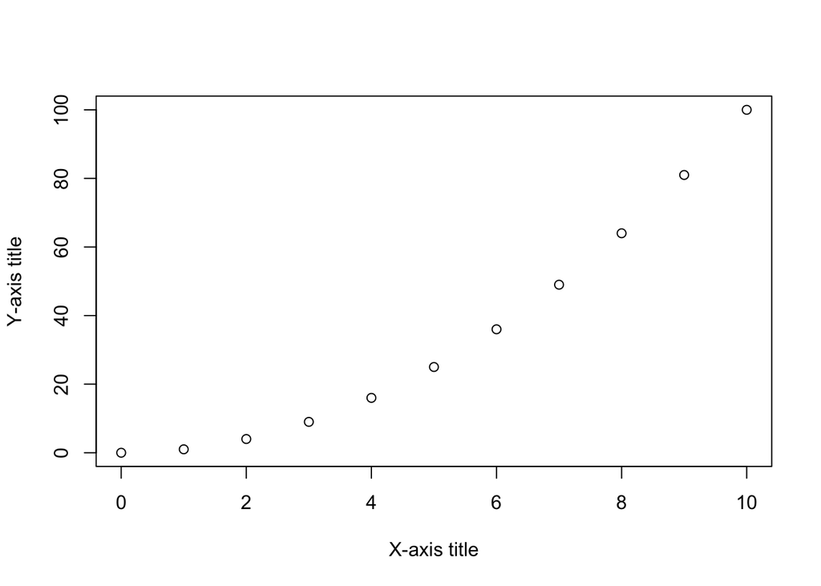

```r
x <- 0:10
y <- x^2

# you can use the plot() function to create a scatter plot
plot(x, y,
     xlab = "X-axis title",
     ylab = "Y-axis title")
```

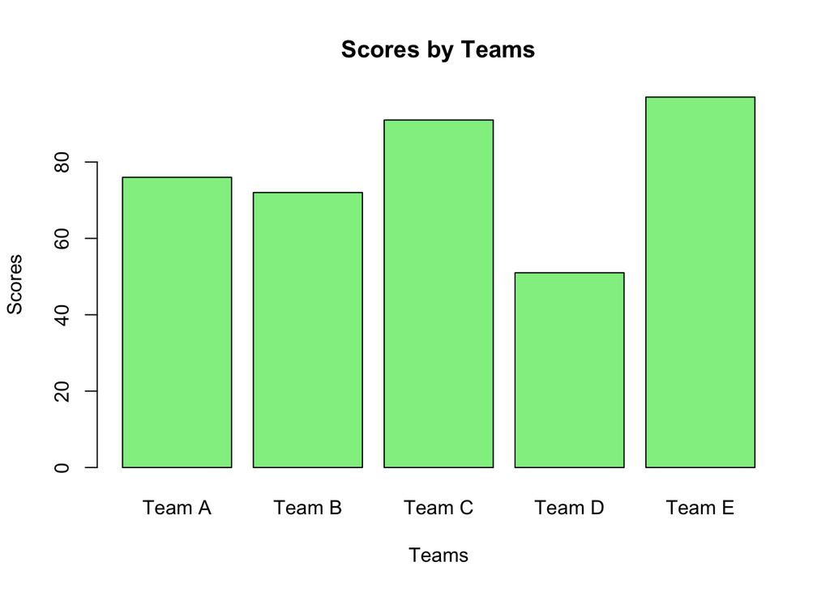

```r
# simulate different data
teams <- c("Team A", "Team B", "Team C", "Team D", "Team E") # generating team names

scores <- sample(50:100, length(teams)) # generating the scores for each team

# bar plot
barplot(scores,
        main = "Scores by Teams",
        xlab = "Teams",
        ylab = "Scores",
        col = "lightgreen",
        border = "black",
        names.arg = teams)
```

We will learn later how to create more advanced visualizations using the ggplot2 package.

## In-Class Exercises

### Exercise 1

Today is Monday. What day of the week will it be 9, 54, 306, and 8999 days from now?

Note: Create a character vector containing the days of the week and repeat this vector 9000 times. Then, use indexing to find the desired day. Hint: Write the days of the week in the character vector starting from Tuesday.

```r
days <- c("Tuesday", "Wednesday", "Thursday", "Friday", "Saturday", "Sunday", "Monday")

# you complete...
```

### Exercise 2

Create a vector containing the numbers 1 to 100. Then, find the sum of the numbers that are divisible by 3 or 5.

Tip: Use the %% operator to find the remainder of a division.

```r
# answer:
numbers <- 1:100

# you complete...
```

### Exercise 3

You are taking measurements every 5 days throughout the year. Create a number sequence that shows on which days you take measurements and assign it to a variable named “measurement_days” The result should look like this: 5, 10, 15, 20… 365.

```r
# answer:


# you complete...
```

## Practice questions for next week

*Q1:* Create a vector containing 50 random numbers with a normal (Gaussian) distribution, mean 20 and standard deviation 2. You can do this with the `rnorm()` function. Then assigns the numbers to a variable and use that variable as an argument to the `sample()` function to randomly select 10 samples from that vector. Run `?rnorm()` `?sample()` to see how the functions work and what arguments they take.

*Q2:* Download and load “LearnBayes” package and take a look at the first few columns of the data set called “studentdata”.

*Answer the following questions:*

3.1. Remove rows that include NA observations.

3.2. Get the number of female students.

3.3. Number of students who are taller than 180 cm (tip: the height is given in inches. please first turn them to cm by multiplying the observations with 2.54)

**See you all next Friday!**

# Week 2 (Dec 1, 2023)

## Answers to Exercise Questions

### Exercise 1

Today is Monday. What day of the week will it be 9, 54, 306, and 8999 days from now?

Note: Create a character vector containing the days of the week and repeat this vector 9000 times. Then, use indexing to find the desired day. Hint: Write the days of the week in the character vector starting from Tuesday.

```r
days <- c("Tuesday", "Wednesday", "Thursday", "Friday", "Saturday", "Sunday", "Monday")

# you complete...

days_rep <- rep(days,9000)

days_rep[9]
```

```
## [1] "Wednesday"
```

```r
days_rep[54]
```

```
## [1] "Saturday"
```

```r
days_rep[306]
```

```
## [1] "Saturday"
```

```r
days_rep[8999]
```

```
## [1] "Friday"
```

```r
# or::

days_rep[c(9,54,306,8999)]
```

```
## [1] "Wednesday" "Saturday"  "Saturday"  "Friday"
```

### Exercise 2

Create a vector containing the numbers 1 to 100. Then, find the sum of the numbers that are divisible by 3 or 5.

Tip: Use the %% operator to find the remainder of a division.

```r
# answer:
numbers <- 1:100

# find numbers that are divisible by 3:

numbers_3_5 <- numbers[numbers %% 3 == 0 | numbers %% 5 == 0]

sum(numbers_3_5)
```

```
## [1] 2418
```

### Exercise 3

You are taking measurements every 5 days throughout the year. Create a number sequence that shows on which days you take measurements and assign it to a variable named “measurement_days” The result should look like this: 5, 10, 15, 20… 365.

```r
# answer:

days <- seq(5,365,5)
days[44]
```

```
## [1] 220
```

## Practice questions for next week

*Q1:* Create a vector containing 50 random numbers with a normal (Gaussian) distribution, mean 20 and standard deviation 2. You can do this with the `rnorm()` function. Then assigns the numbers to a variable and use that variable as an argument to the `sample()` function to randomly select 10 samples from that vector. Run `?rnorm()` `?sample()` to see how the functions work and what arguments they take.

```r
dist <- round(rnorm(n=50, mean=20, sd=2))

sample(dist, 10)
```

```
##  [1] 21 19 19 20 20 19 22 20 21 19
```

*Q2:* Download and load “LearnBayes” package and take a look at the first few columns of the data set called “studentdata”.

*Answer the following questions:*

3.1. Remove rows that include NA observations.

```r
#install.packages("LearnBayes")
library(LearnBayes)
df <- studentdata

dim(df)
```

```
## [1] 657  11
```

```r
sum(is.na(df))
```

```
## [1] 118
```

```r
df <- na.omit(df)

dim(df)
```

```
## [1] 559  11
```

```r
sum(is.na(df))
```

```
## [1] 0
```

3.2. Get the number of female students.

```r
# alt 1:
gender <- df$Gender
length(gender[gender == "female"])
```

```
## [1] 364
```

```r
# alt 2:
length(df$Gender[df$Gender == "female"])
```

```
## [1] 364
```

```r
# alt 3:
#install.packages("tidyverse")
library(tidyverse)
nrow(filter(df, Gender == "female"))
```

```
## [1] 364
```

```r
# Find percetange of female students
nrow(filter(df, Gender == "female")) / nrow(df)*100
```

```
## [1] 65.11628
```

3.3. Number of students who are taller than 180 cm (tip: the height is given in inches. please first turn them to cm by multiplying the observations with 2.54)

```r
# You can use dplyr's mutate() function to change values in a dataset
library(dplyr)

df <- mutate(df, Height = Height * 2.54)

nrow(filter(df, Height > 180))
```

```
## [1] 115
```

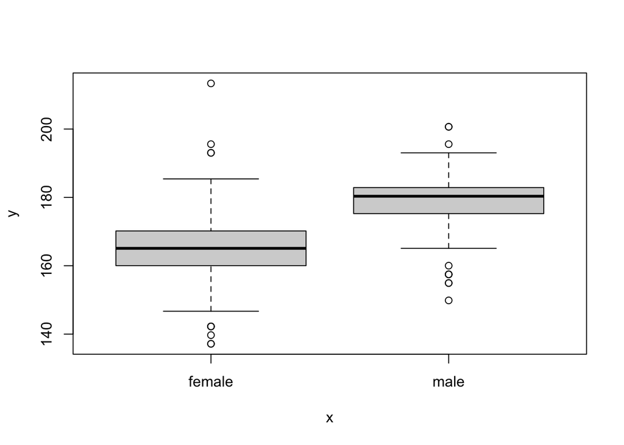

```r
plot(df$Gender, df$Height)
```

## Data Manipulation: In-class practice

Now, let’s practice a bit more. Follow these steps:

We will now work with COVID-19 dataset. Let’s import it to our R session.

*Source*: https://github.com/sadettindemirel/Covid19-Turkey

When working with data, it’s important to create a workspace folder that contains both your data and R script. You can either download the .csv file and import it to R this way. Make sure that you set your working directory to the correct folder by going to Session -> Set Working Directory -> To Source File Location.

```r
df_covid <- read_csv("http://kelesonur.github.io/compec-r/covid_sayi.csv")
head(df_covid)
```

```
## # A tibble: 6 × 12
##   tarih      gunluk_test gunluk_vaka gunluk_olum gunluk_iyilesen toplam_test
##   <date>           <dbl>       <dbl>       <dbl>           <dbl>       <dbl>
## 1 2020-03-11           0           1           0               0           0
## 2 2020-03-12           0           0           0               0           0
## 3 2020-03-13           0           4           0               0           0
## 4 2020-03-14           0           1           0               0           0
## 5 2020-03-15           0          12           1               0           0
## 6 2020-03-16           0          29           0               0           0
## # … with 6 more variables: toplam_vaka <dbl>, toplam_olum <dbl>,
## #   toplam_iyilesen <dbl>, yogun_bakim_hasta <dbl>, toplam_intube <dbl>,
## #   agir_hasta <dbl>
```

1. Create a histogram (of daily death toll) and time-series plot (x: time, y: daily death toll). You can use hist() and `boxplot()` functions respectively to do that. Add label names.

```r
# Your turn:
```

2. How many cases of COVID were detected and how many people died on July 20, 2020?

```r
# Your turn:
```

3. Can you show the total number of COVID deaths and patients in intensive care between 2020-03-11 and 2020-07-20 in the timeline graph? Tip: You can use indexing to filter the dates and save them as a new data frame.

```r
# Your turn:
```

## Data Manipulation with Tidyverse

So far, we have examined data frames using Base R, that is, the functions and operators native to R. However, today most data scientists using R do not process data with these, but with the more modern “Tidyverse” packages.

These packages make organizing data much easier and more practical (Wickham, 2017).

Let’s look at some important packages within Tidyverse:

1. tibble: `as.tibble()`
2. readr: `read_csv()`
3. dplyr: `subset(), select(), filter(), summarize()` and more…
4. magrittr: `%>%` operator
5. ggplot2: `ggplot()`

```r
library(tidyverse)
```

### Tibble

Tibble is essentially a more modern version of data frames in R. Here’s where Tibbles are superior to data frames: There is no need to use the head() function. It automatically shows us the first 10 rows. There is no need to use `nrow()` and `ncol()`. This information is included in the table. tells us the type of vectors in each column (character, integer, etc.)

```r
df <- starwars
df <- as.tibble(df)
head(df)
```

```
## # A tibble: 6 × 14
##   name      height  mass hair_color skin_color eye_color birth_year sex   gender
##   <chr>      <int> <dbl> <chr>      <chr>      <chr>          <dbl> <chr> <chr>
## 1 Luke Sky…    172    77 blond      fair       blue            19   male  mascu…
## 2 C-3PO        167    75 <NA>       gold       yellow         112   none  mascu…
## 3 R2-D2         96    32 <NA>       white, bl… red             33   none  mascu…
## 4 Darth Va…    202   136 none       white      yellow          41.9 male  mascu…
## 5 Leia Org…    150    49 brown      light      brown           19   fema… femin…
## 6 Owen Lars    178   120 brown, gr… light      blue            52   male  mascu…
## # … with 5 more variables: homeworld <chr>, species <chr>, films <list>,
## #   vehicles <list>, starships <list>
```

### Data manipulation with dplyr

dplyr is the most practical package for editing data frames or tibbles. Let’s see what we can do with the functions included in it. For this we will use a dataset from a package called `gapminder`:

| country | continent | year | lifeExp | pop | gdpPercap |
| --- | --- | --- | --- | --- | --- |
| Afghanistan | Asia | 1952 | 28.801 | 8425333 | 779.4453 |
| Afghanistan | Asia | 1957 | 30.332 | 9240934 | 820.8530 |
| Afghanistan | Asia | 1962 | 31.997 | 10267083 | 853.1007 |
| Afghanistan | Asia | 1967 | 34.020 | 11537966 | 836.1971 |
| Afghanistan | Asia | 1972 | 36.088 | 13079460 | 739.9811 |
| Afghanistan | Asia | 1977 | 38.438 | 14880372 | 786.1134 |

Let’s load the data:

```r
library(gapminder)

df <- gapminder
```

#### `filter()` function

We can easily filter the data we want by using this function:

```r
filter(df,country == "Turkey")

filter(df, year > 2002)

filter(df, year > 2002 & country == "Germany")
```

How can you filter for multiple countries? Any guesses?

#### `select()` function:

`select()` function allows us to select only the columns we want:

```r
select(df, country, pop, year) # only tak

select(df, -continent) # kıta hariç bütün sütunları al

select(df, pop:gdpPercap) # nüfustan gdp'ye kadar bütün sütunları al
```

#### `rename()` function:

We can change the names of the columns we want with this. If we want this to be saved, we need to overwrite the variable:

```r
library(dplyr)
df <- rename(df, Country = country, CONTINENT = continent, YEAR = year, LifeExpectancy = lifeExp)

head(df)

# Extra: clean the column names
library(janitor)
df_cleaned <- clean_names(df)
```

#### `mutate()` function:

We can make changes to a tibble with the mutate() function.

For example, let’s create a new column and write the population there as one per million:

```r
df_mutated <- mutate(df_cleaned, pop_million = pop / 1000000)

head(df_mutated)
```

```
## # A tibble: 6 × 7
##   country     continent  year life_expectancy      pop gdp_percap pop_million
##   <fct>       <fct>     <int>           <dbl>    <int>      <dbl>       <dbl>
## 1 Afghanistan Asia       1952            28.8  8425333       779.        8.43
## 2 Afghanistan Asia       1957            30.3  9240934       821.        9.24
## 3 Afghanistan Asia       1962            32.0 10267083       853.       10.3
## 4 Afghanistan Asia       1967            34.0 11537966       836.       11.5
## 5 Afghanistan Asia       1972            36.1 13079460       740.       13.1
## 6 Afghanistan Asia       1977            38.4 14880372       786.       14.9
```

#### `arrange()` function:

```r
# sort increasingly

arrange(df_mutated, continent)

arrange(df_mutated, gdp_percap)

# sort in an descending order

arrange(df_mutated, desc(year))
```

### Pipe with the magrittr package

The pipe operator is represented by the symbol %>%. This operator takes the variable on its left and places it as the first argument of the function on its right. This operator will be preferred instead of using nested and long functions. This saves us from hard-to-read and nested functions and helps us follow a linear order:

```r
filter(df_mutated, country == "Turkey") # previous method

df_mutated %>% filter(country == "Turkey") # with pipe

select(filter(df_mutated, country == "Turkey" & year == "2007"), pop) # previous method

df_mutated %>% filter(country == "Turkey" & year == "2007") %>% select(pop) # pipe ile
```

### Visualization with the ggplot2 package

### Scatterplots

You can use `geom_point().`

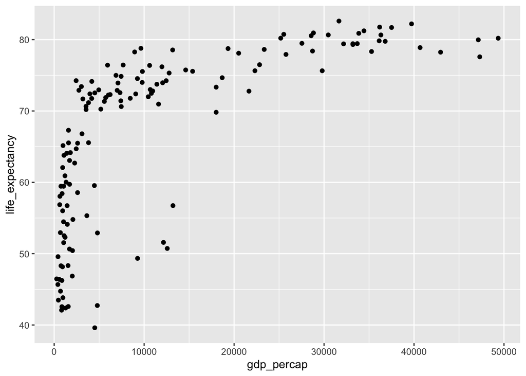

```r
library(ggplot2)

df_mutated %>% filter(year == 2007) %>%
ggplot(aes(x=gdp_percap, y=life_expectancy)) +
 geom_point()
```

Or you can try using `geom_jitter()` or `geom_violin()`

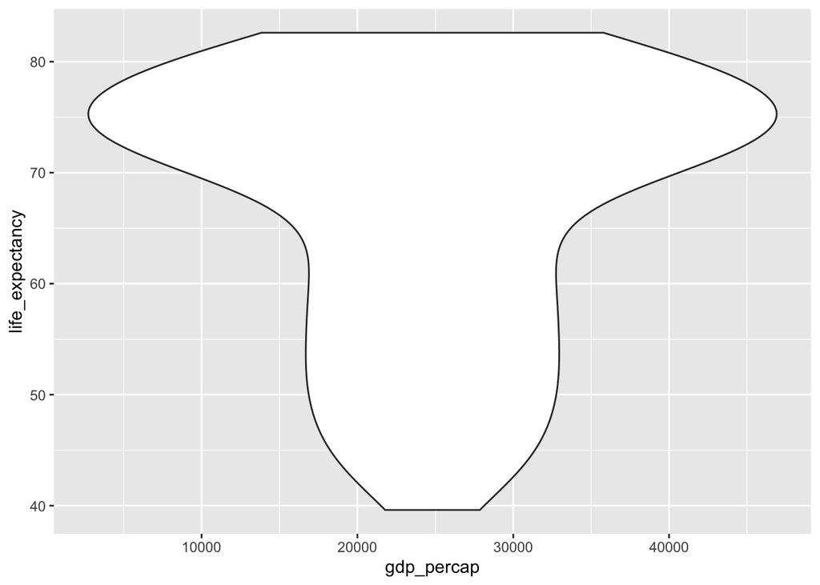

```r
df_mutated %>% filter(year == 2007) %>%
ggplot(aes(x=gdp_percap, y=life_expectancy)) +
 geom_violin()
```

You can use text labels.

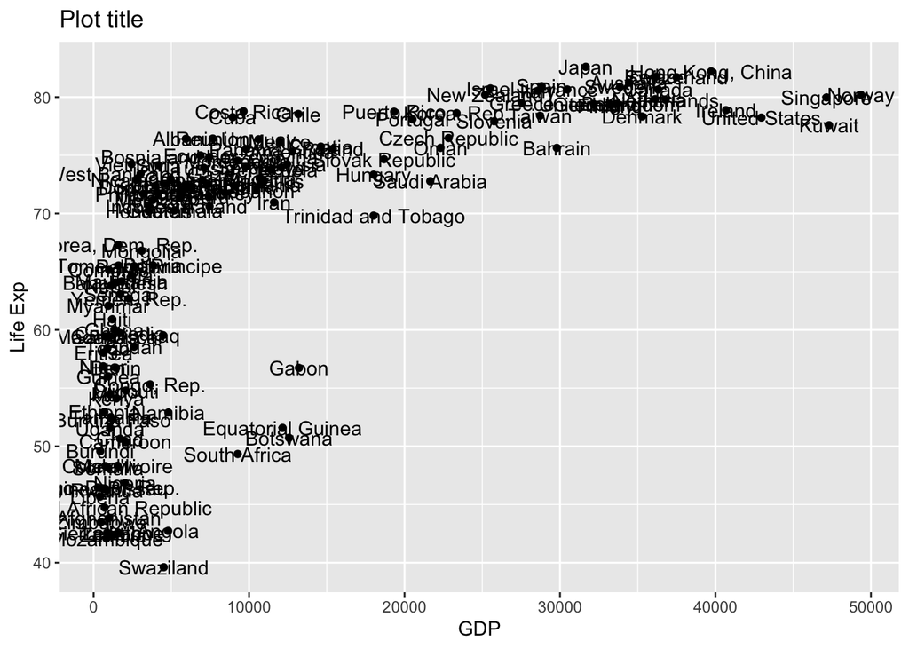

```r
p1 <- df_mutated %>% filter(year == 2007) %>%
  ggplot(aes(x=gdp_percap, y=life_expectancy, label = country)) +
  geom_point() +
  geom_text()

p1 + ggtitle("Plot title") + xlab("GDP") + ylab("Life Exp")
```

```r
# save it
# ggsave('plot1.png', width = 8, height = 6)
```

Using the color option:

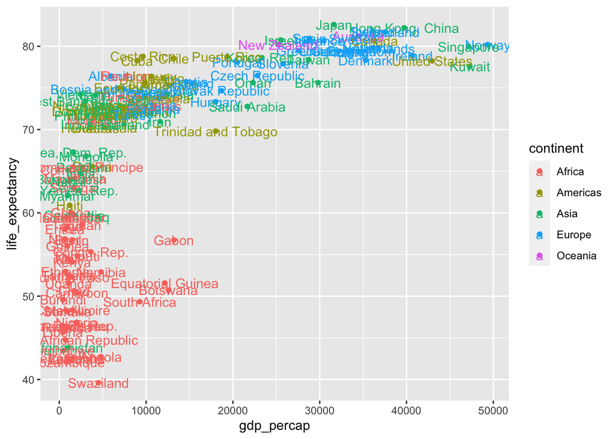

```r
df_mutated %>% filter(year == 2007) %>%
  ggplot(aes(x=gdp_percap, y=life_expectancy, label = country, color = continent)) +
  geom_point() +
  geom_text()
```

Add new facets:

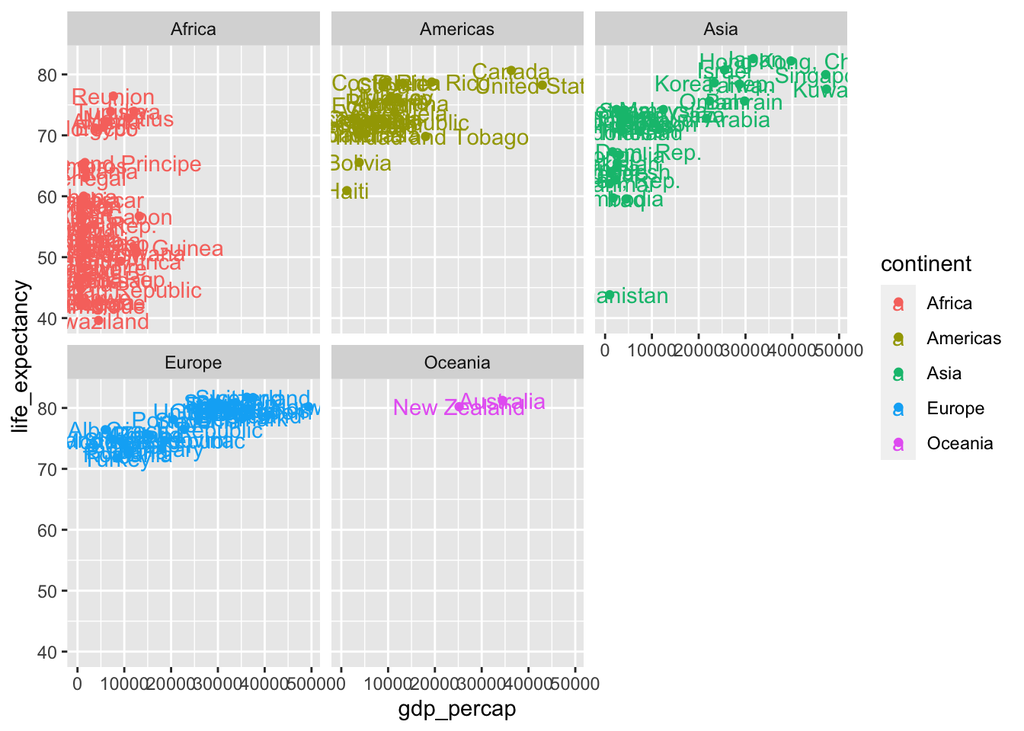

```r
 df_mutated %>% filter(year == 2007) %>%
  ggplot(aes(x=gdp_percap, y=life_expectancy, label = country, color = continent)) +
  geom_point() +
  geom_text() +
  facet_wrap(~continent)
```

### Bar plots

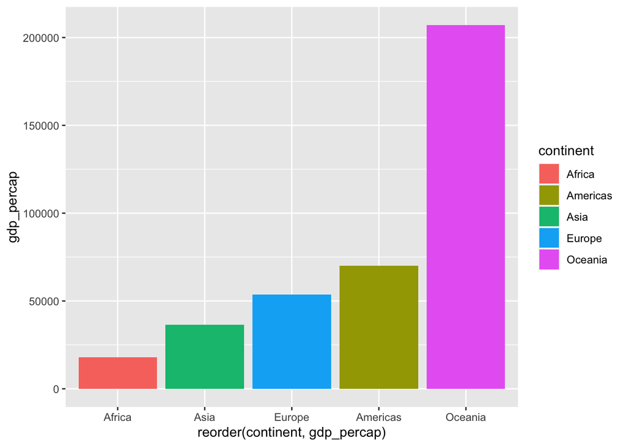

```r
df_mutated %>% filter(country %in% c("Turkey","Brazil","Thailand","Nigeria","New Zealand")) %>%
  ggplot(aes(x = reorder(continent,gdp_percap), y = gdp_percap, fill = continent)) +
  geom_bar(stat="identity")
```

## In-class Exercises

1. What years of information are included in the Gapminder data? Tip: You can find this out with the `unique()` command.

```r
# Your answer:
```

2. What are the mean and median of life years in 1962 and 2002? Tip: You can do this with the `filter()` and `select()` functions.

```r
# Your answer:
```

```r
# Your answer:
```

4. Can you create a line plot and show Turkey’s population growth? Can you name the plot and axes? Tip: you will need to use the `geom_line()` function to create the line chart.

```r
# Your answer:
```